# Przygotowanie danych - projekt

**Size.L.** *Wykresy przed analizą wartości skrajnych*

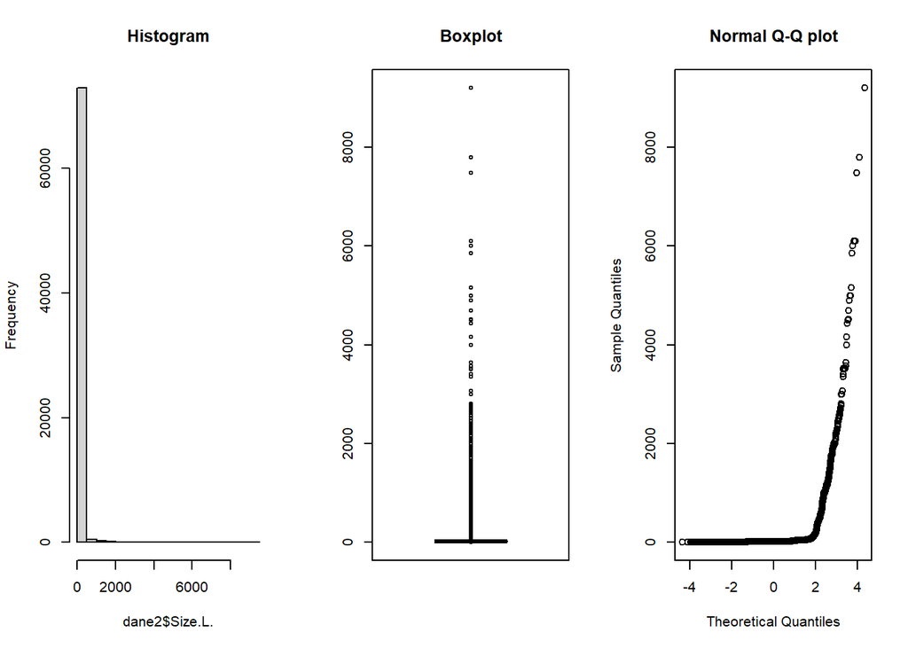

```r
par(mfrow = c(1, 3))
hist(dane2$Size.L., main = "Histogram")
boxplot(dane2$Size.L., main = "Boxplot")
qqnorm(dane2$Size.L., main = "Normal Q-Q plot")
```

*Sprawdzenie czy zmienna ma rozkład normalny*

```r
ks.test(dane2$Size.L., 'pnorm')
```

```
##
##  One-sample Kolmogorov-Smirnov test
##
## data:  dane2$Size.L.
## D = 0.9983, p-value < 2.2e-16
## alternative hypothesis: two-sided
```

**Wniosek: Zmienna nie ma rozkładu normalnego**

*Identyfikacja wartości skrajnych*

```r
#średnia i odchylenie standardowe
mean = mean(dane3$Size.L.)
std = sd(dane3$Size.L.)

#wykorzystanie reguły 3 odchyleń
Tmin = mean-(3*std)
Tmax = mean+(3*std)

#znalezienie wartości skrajnych
head(dane3$Size.L.[which(dane3$Size.L. < Tmin | dane3$Size.L. > Tmax)],10)
```

```
##  [1]  643.52  904.71 2200.00  681.37  870.64  605.67  957.71 1760.22 6000.00
## [10] 2300.00
```

```r
#usunięcie wartości skrajnych
dane3$id <- seq(1, length(dane3$StyleID))
ids <- dane3$id[which(dane3$Size.L. > Tmin & dane3$Size.L. < Tmax)]
dane4 <- subset(dane3[ids, ])
head(dane4,5)
```

```
##   BeerID StyleID Size.L.    OG    FG  ABV   IBU Color BoilSize BoilTime
## 1      1      45   21.77 1.004 1.004 5.48 17.65  4.83    28.39       75
## 2      2      85   20.82 1.004 1.004 8.16 60.65 15.64    24.61       60
## 3      3       7   18.93 1.004 1.004 5.91 59.25  8.98    22.71       60
## 4      4       7   22.71 1.004 1.004 5.80 54.48   8.5    26.50       60
## 5      5      20   50.00 1.004 1.004 6.48 17.84  4.57    60.00       90
##   BoilGravity Efficiency MashThickness BrewMethod PrimaryTemp id
## 1       1.004         70         2.127  All Grain          94  1
## 2       1.004         70         2.127  All Grain         121  2
## 3       1.005         70         2.127    extract         121  3
## 4       1.005         70         2.127  All Grain         121  4
## 5       1.004         72         2.127  All Grain         111  5
```

*Wykresy po analizie wartości skrajnych*

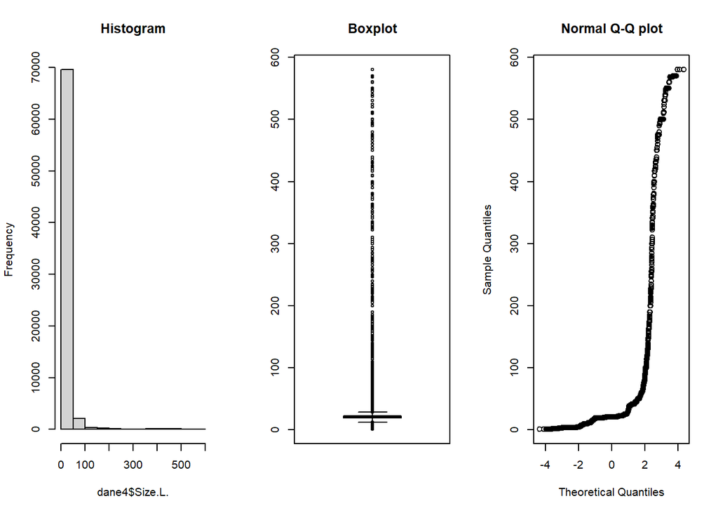

```r
par(mfrow = c(1, 3))
hist(dane4$Size.L., main = "Histogram")
boxplot(dane4$Size.L., main = "Boxplot")
qqnorm(dane4$Size.L., main = "Normal Q-Q plot")
```

**OG** *Wykresy przed analizą wartości skrajnych*

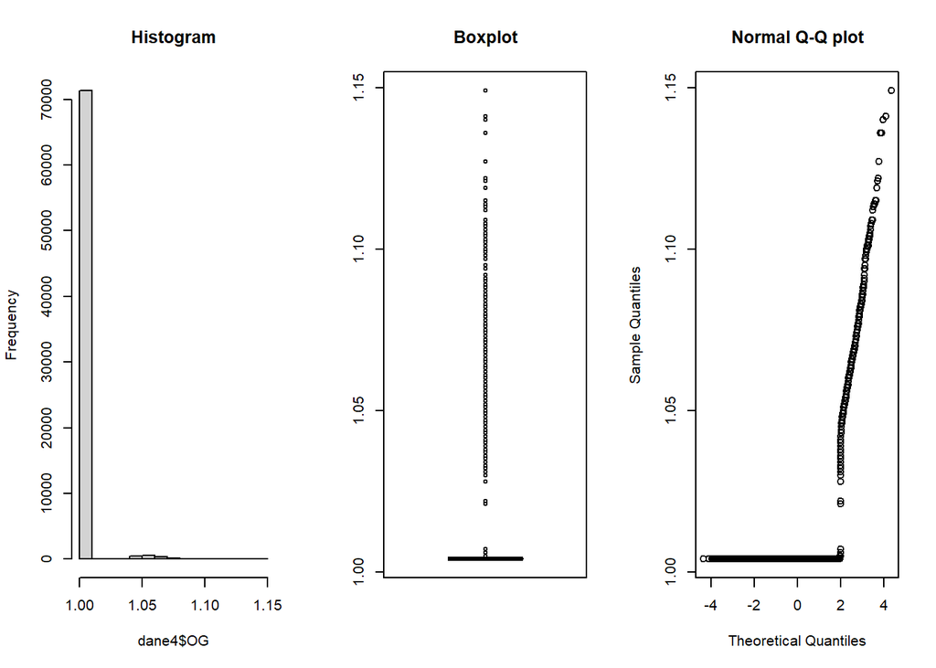

```r
par(mfrow = c(1, 3))
hist(dane4$OG, main = "Histogram")
boxplot(dane4$OG, main = "Boxplot")
qqnorm(dane4$OG, main = "Normal Q-Q plot")
```

*Sprawdzenie czy zmienna ma rozkład normalny*

```r
ks.test(dane4$OG, 'pnorm')
```

```
##
##  One-sample Kolmogorov-Smirnov test
##
## data:  dane4$OG
## D = 0.84231, p-value < 2.2e-16
## alternative hypothesis: two-sided
```

**Wniosek: Zmienna nie ma rozkładu normalnego**

*Identyfikacja wartości skrajnych*

```r
#średnia i odchylenie standardowe
length(dane4$BeerID)
```

```
## [1] 72974
```

```r
mean = mean(dane4$OG)
std = sd(dane4$OG)

#wykorzystanie reguły 3 odchyleń
Tmin = mean-(3*std)
Tmax = mean+(3*std)

#znalezienie wartości skrajnych
head(dane4$OG[which(dane4$OG < Tmin | dane4$OG > Tmax)],10)
```

```
##  [1] 1.057 1.061 1.053 1.068 1.063 1.055 1.100 1.081 1.053 1.057
```

```r
#usunięcie wartości skrajnych
dane4$id <- seq(1, length(dane4$StyleID))
ids <- dane4$id[which(dane4$OG > Tmin & dane4$OG < Tmax)]
dane5 <- subset(dane4[ids, ])
head(dane5,5)
```

```
##   BeerID StyleID Size.L.    OG    FG  ABV   IBU Color BoilSize BoilTime
## 1      1      45   21.77 1.004 1.004 5.48 17.65  4.83    28.39       75
## 2      2      85   20.82 1.004 1.004 8.16 60.65 15.64    24.61       60
## 3      3       7   18.93 1.004 1.004 5.91 59.25  8.98    22.71       60
## 4      4       7   22.71 1.004 1.004 5.80 54.48   8.5    26.50       60
## 5      5      20   50.00 1.004 1.004 6.48 17.84  4.57    60.00       90
##   BoilGravity Efficiency MashThickness BrewMethod PrimaryTemp id
## 1       1.004         70         2.127  All Grain          94  1
## 2       1.004         70         2.127  All Grain         121  2
## 3       1.005         70         2.127    extract         121  3
## 4       1.005         70         2.127  All Grain         121  4
## 5       1.004         72         2.127  All Grain         111  5
```

*Wykresy po analizie wartości skrajnych*

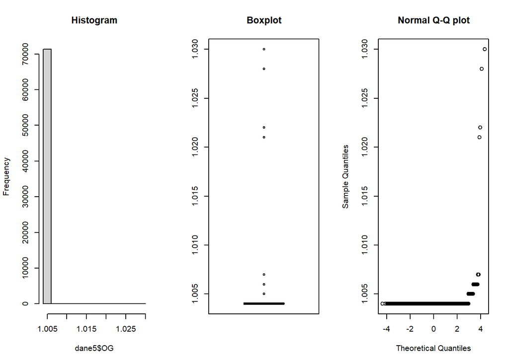

```r
par(mfrow = c(1, 3))
hist(dane5$OG, main = "Histogram")
boxplot(dane5$OG, main = "Boxplot")
qqnorm(dane5$OG, main = "Normal Q-Q plot")
```

**FG** *Wykresy przed analizą wartości skrajnych*

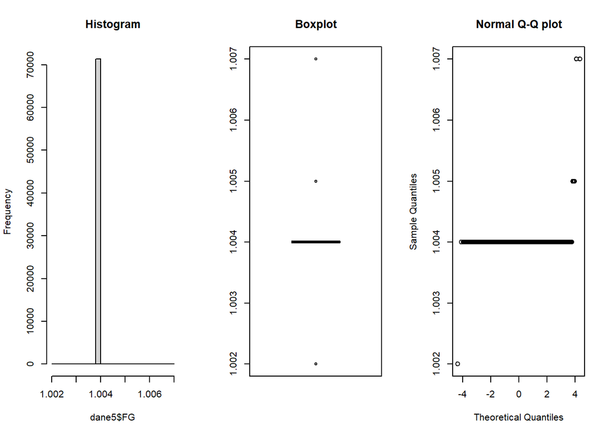

```r
par(mfrow = c(1, 3))
hist(dane5$FG, main = "Histogram")
boxplot(dane5$FG, main = "Boxplot")
qqnorm(dane5$FG, main = "Normal Q-Q plot")
```

*Sprawdzenie czy zmienna ma rozkład normalny*

```r
ks.test(dane5$FG, 'pnorm')
```

```
##
##  One-sample Kolmogorov-Smirnov test
##
## data:  dane5$FG
## D = 0.8423, p-value < 2.2e-16
## alternative hypothesis: two-sided
```

**Wniosek: Zmienna nie ma rozkładu normalnego**

*Identyfikacja wartości skrajnych*

```r
#średnia i odchylenie standardowe
length(dane5$BeerID)
```

```
## [1] 71305
```

```r
mean = mean(dane5$FG)
std = sd(dane5$FG)

#wykorzystanie reguły 3 odchyleń
Tmin = mean-(3*std)
Tmax = mean+(3*std)

#znalezienie wartości skrajnych
head(dane5$FG[which(dane5$FG < Tmin | dane5$FG > Tmax)],10)
```

```
## [1] 1.002 1.005 1.007 1.005 1.005 1.007
```

```r
#usunięcie wartości skrajnych
dane5$id <- seq(1, length(dane5$StyleID))
ids <- dane5$id[which(dane5$FG > Tmin & dane5$FG < Tmax)]
dane6 <- dane5
head(dane6,5)
```

```
##   BeerID StyleID Size.L.    OG    FG  ABV   IBU Color BoilSize BoilTime
## 1      1      45   21.77 1.004 1.004 5.48 17.65  4.83    28.39       75
## 2      2      85   20.82 1.004 1.004 8.16 60.65 15.64    24.61       60
## 3      3       7   18.93 1.004 1.004 5.91 59.25  8.98    22.71       60
## 4      4       7   22.71 1.004 1.004 5.80 54.48   8.5    26.50       60
## 5      5      20   50.00 1.004 1.004 6.48 17.84  4.57    60.00       90
##   BoilGravity Efficiency MashThickness BrewMethod PrimaryTemp id
## 1       1.004         70         2.127  All Grain          94  1
## 2       1.004         70         2.127  All Grain         121  2
## 3       1.005         70         2.127    extract         121  3
## 4       1.005         70         2.127  All Grain         121  4
## 5       1.004         72         2.127  All Grain         111  5
```

**Ze zmiennej `FG` wartości skrajne nie będą usuwane.**

**ABV** *Wykresy przed analizą wartości skrajnych*

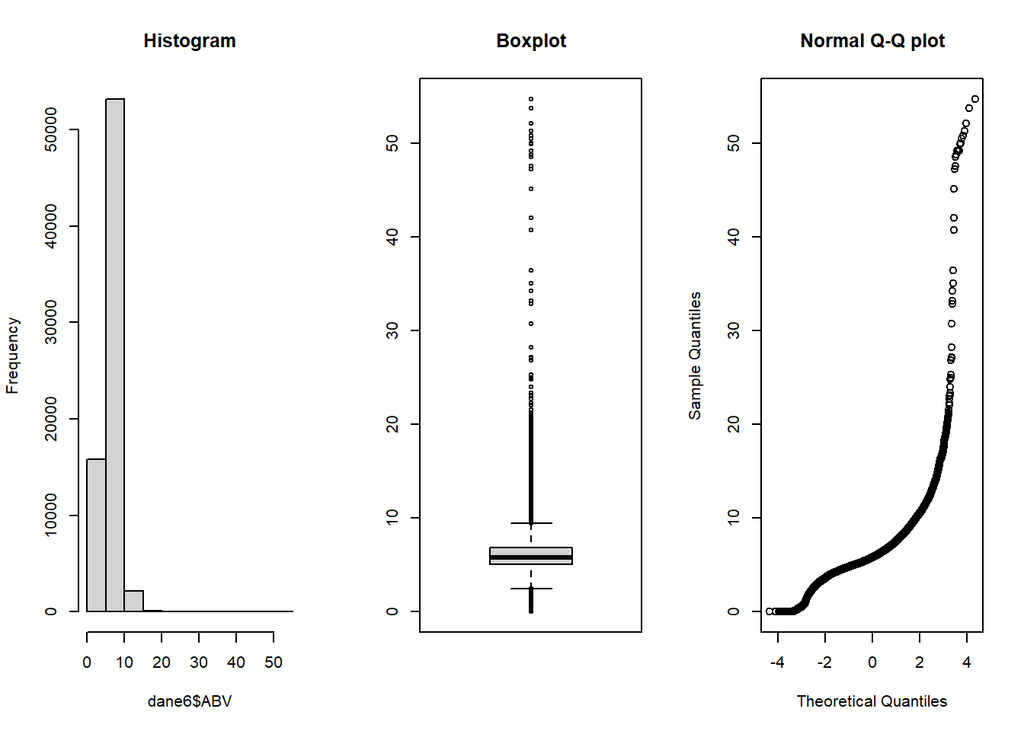

```r
par(mfrow = c(1, 3))
hist(dane6$ABV, main = "Histogram")
boxplot(dane6$ABV, main = "Boxplot")
qqnorm(dane6$ABV, main = "Normal Q-Q plot")
```

*Sprawdzenie czy zmienna ma rozkład normalny*

```r
ks.test(dane6$ABV, 'pnorm')
```

```
##
##  One-sample Kolmogorov-Smirnov test
##
## data:  dane6$ABV
## D = 0.98913, p-value < 2.2e-16
## alternative hypothesis: two-sided
```

**Wniosek: Zmienna nie ma rozkładu normalnego**

*Identyfikacja wartości skrajnych*

```r
#średnia i odchylenie standardowe
length(dane6$BeerID)
```

```
## [1] 71305
```

```r
mean = mean(dane6$ABV)
std = sd(dane6$ABV)

#wykorzystanie reguły 3 odchyleń
Tmin = mean-(3*std)
Tmax = mean+(3*std)

#znalezienie wartości skrajnych
head(dane6$ABV[which(dane6$ABV < Tmin | dane6$ABV > Tmax)],10)
```

```
##  [1] 13.24 12.35 19.85 16.38 12.22 13.69 14.61 13.23 18.81 27.12
```

```r
#usunięcie wartości skrajnych
dane6$id <- seq(1, length(dane6$StyleID))
ids <- dane6$id[which(dane6$ABV > Tmin & dane6$ABV < Tmax)]
dane7 <- subset(dane6[ids, ])
head(dane7,5)
```

```
##   BeerID StyleID Size.L.    OG    FG  ABV   IBU Color BoilSize BoilTime
## 1      1      45   21.77 1.004 1.004 5.48 17.65  4.83    28.39       75
## 2      2      85   20.82 1.004 1.004 8.16 60.65 15.64    24.61       60
## 3      3       7   18.93 1.004 1.004 5.91 59.25  8.98    22.71       60
## 4      4       7   22.71 1.004 1.004 5.80 54.48   8.5    26.50       60
## 5      5      20   50.00 1.004 1.004 6.48 17.84  4.57    60.00       90
##   BoilGravity Efficiency MashThickness BrewMethod PrimaryTemp id
## 1       1.004         70         2.127  All Grain          94  1
## 2       1.004         70         2.127  All Grain         121  2
## 3       1.005         70         2.127    extract         121  3
## 4       1.005         70         2.127  All Grain         121  4
## 5       1.004         72         2.127  All Grain         111  5
```

*Wykresy po analizie wartości skrajnych*

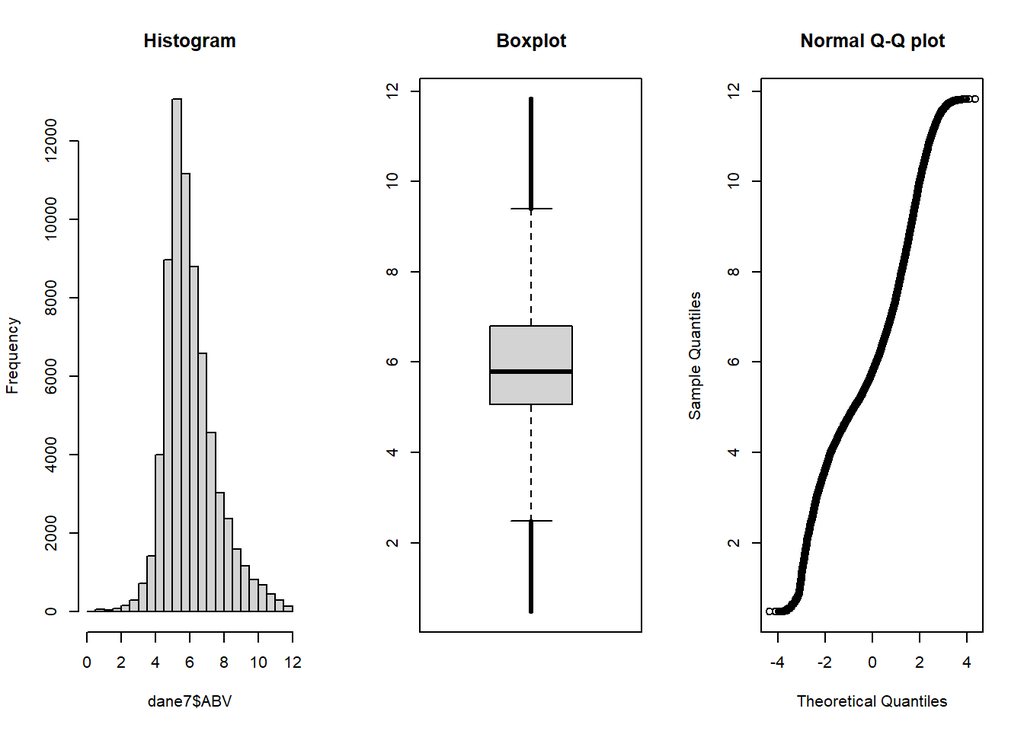

```r
par(mfrow = c(1, 3))
hist(dane7$ABV, main = "Histogram")
boxplot(dane7$ABV, main = "Boxplot")
qqnorm(dane7$ABV, main = "Normal Q-Q plot")
```

**IBU - zmienna będzie podlegać analizie wartości skrajnych, ponieważ są to jednostki gorzkości wyrażone w liczbach** *Wykresy przed analizą wartości skrajnych*

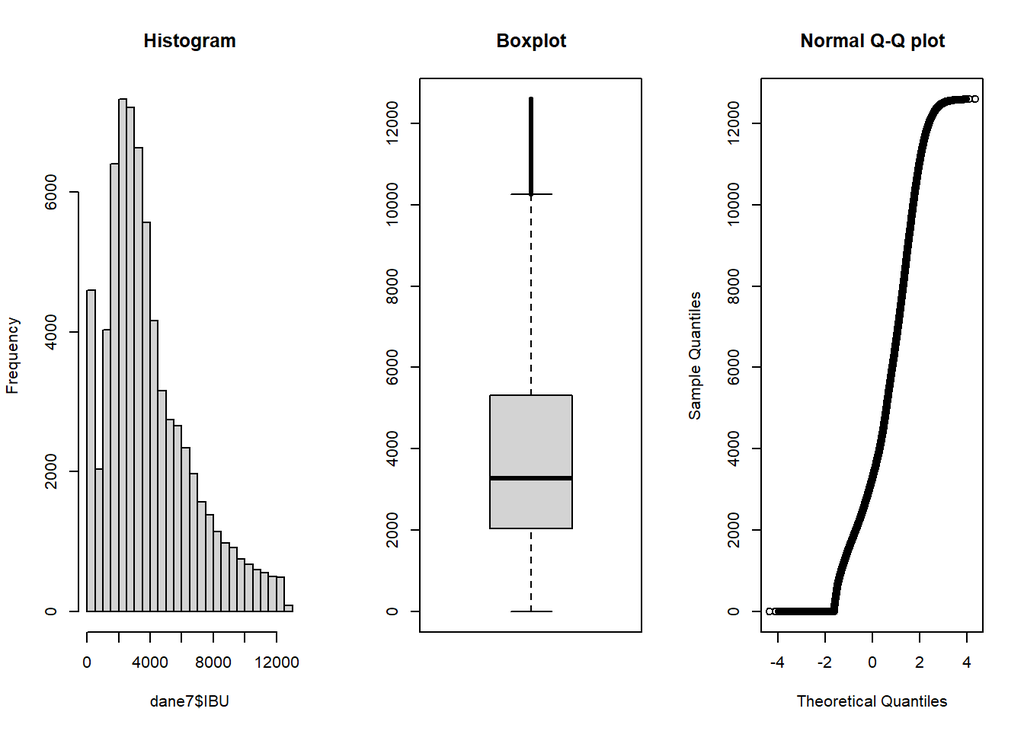

```r
dane7$IBU<-as.numeric(dane7$IBU)
par(mfrow = c(1, 3))
hist(dane7$IBU, main = "Histogram")
boxplot(dane7$IBU, main = "Boxplot")
qqnorm(dane7$IBU, main = "Normal Q-Q plot")
```

*Sprawdzenie czy zmienna ma rozkład normalny*

```r
ks.test(dane7$IBU, 'pnorm')
```

```
##
##  One-sample Kolmogorov-Smirnov test
##
## data:  dane7$IBU
## D = 0.94768, p-value < 2.2e-16
## alternative hypothesis: two-sided
```

**Wniosek: Zmienna nie ma rozkładu normalnego**

*Identyfikacja wartości skrajnych*

```r
#średnia i odchylenie standardowe
length(dane7$BeerID)
```

```
## [1] 70484
```

```r
mean = mean(dane7$IBU)
std = sd(dane7$IBU)

#wykorzystanie reguły 3 odchyleń
Tmin = mean-(3*std)
Tmax = mean+(3*std)

#znalezienie wartości skrajnych
head(dane7$IBU[which(dane7$IBU < Tmin | dane7$IBU > Tmax)],10)
```

```
##  [1] 12383 12509 12473 12331 12518 12574 12104 12090 12319 12290
```

```r
#usunięcie wartości skrajnych
dane7$id <- seq(1, length(dane7$StyleID))
ids <- dane7$id[which(dane7$IBU > Tmin & dane7$IBU < Tmax)]
dane8 <- subset(dane7[ids, ])
head(dane8,5)
```

```
##   BeerID StyleID Size.L.    OG    FG  ABV  IBU Color BoilSize BoilTime
## 1      1      45   21.77 1.004 1.004 5.48 1453  4.83    28.39       75
## 2      2      85   20.82 1.004 1.004 8.16 5749 15.64    24.61       60
## 3      3       7   18.93 1.004 1.004 5.91 5610  8.98    22.71       60
## 4      4       7   22.71 1.004 1.004 5.80 5136   8.5    26.50       60
## 5      5      20   50.00 1.004 1.004 6.48 1472  4.57    60.00       90
##   BoilGravity Efficiency MashThickness BrewMethod PrimaryTemp id
## 1       1.004         70         2.127  All Grain          94  1
## 2       1.004         70         2.127  All Grain         121  2
## 3       1.005         70         2.127    extract         121  3
## 4       1.005         70         2.127  All Grain         121  4
## 5       1.004         72         2.127  All Grain         111  5
```

*Wykresy po analizie wartości skrajnych*

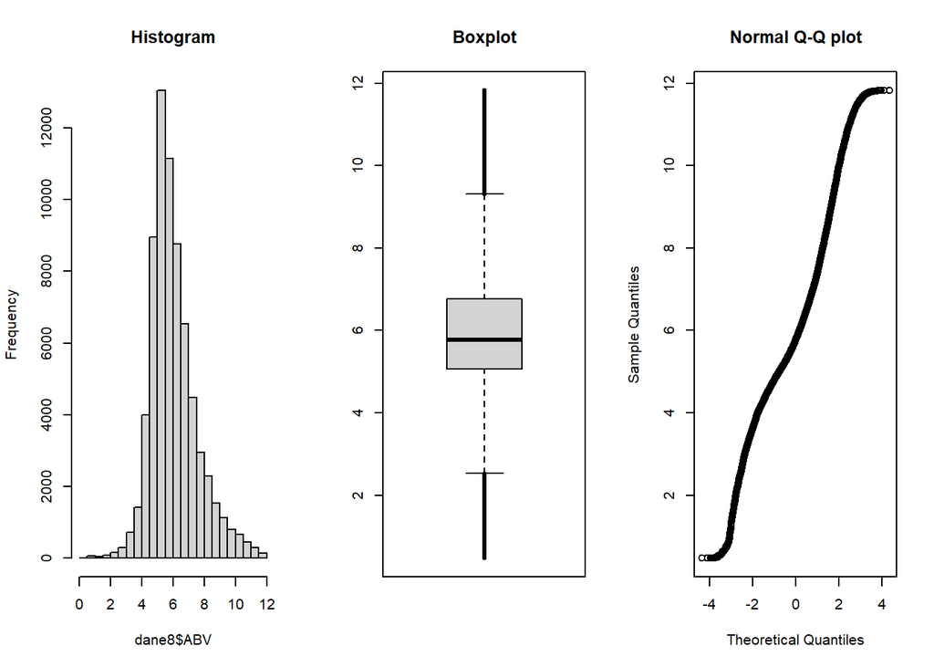

```r
par(mfrow = c(1, 3))
hist(dane8$ABV, main = "Histogram")
boxplot(dane8$ABV, main = "Boxplot")
qqnorm(dane8$ABV, main = "Normal Q-Q plot")
```

**Color - zmienna będzie podlegać analizie wartości skrajnych, ponieważ są kolory są przedstawione w postaci etykiet liczbowych** *Wykresy przed analizą wartości skrajnych*

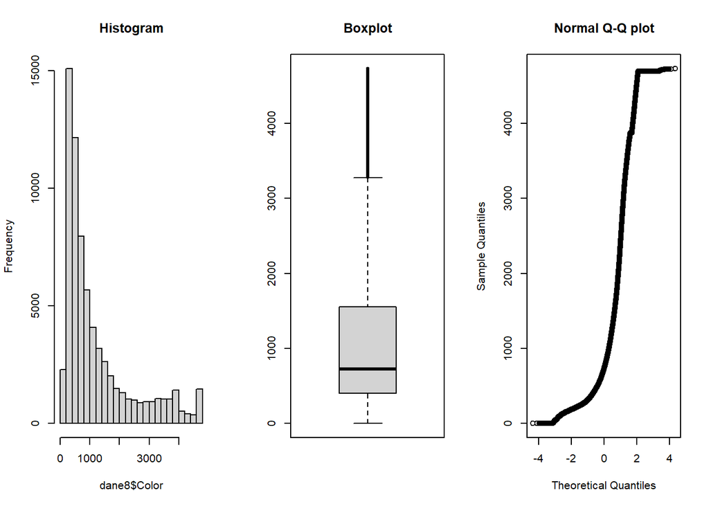

```r
dane8$Color<-as.numeric(dane8$Color)
par(mfrow = c(1, 3))
hist(dane8$Color, main = "Histogram")
boxplot(dane8$Color, main = "Boxplot")
qqnorm(dane8$Color, main = "Normal Q-Q plot")
```

*Sprawdzenie czy zmienna ma rozkład normalny*

```r
ks.test(dane8$Color, 'pnorm')
```

```
##
##  One-sample Kolmogorov-Smirnov test
##
## data:  dane8$Color
## D = 0.99907, p-value < 2.2e-16
## alternative hypothesis: two-sided
```

**Wniosek: Zmienna nie ma rozkładu normalnego**

*Identyfikacja wartości skrajnych*

```r
#średnia i odchylenie standardowe
length(dane8$BeerID)
```

```
## [1] 69940
```

```r
mean = mean(dane8$Color)
std = sd(dane8$Color)

#wykorzystanie reguły 3 odchyleń
Tmin = mean-(3*std)
Tmax = mean+(3*std)

#znalezienie wartości skrajnych
head(dane8$Color[which(dane8$Color < Tmin | dane8$Color > Tmax)],10)
```

```
##  [1] 4693 4693 4693 4693 4697 4693 4693 4693 4693 4693
```

```r
#usunięcie wartości skrajnych
dane8$id <- seq(1, length(dane8$StyleID))
ids <- dane8$id[which(dane8$Color > Tmin & dane8$Color < Tmax)]
dane9 <- subset(dane8[ids, ])
head(dane9,5)
```

```
##   BeerID StyleID Size.L.    OG    FG  ABV  IBU Color BoilSize BoilTime
## 1      1      45   21.77 1.004 1.004 5.48 1453   367    28.39       75
## 2      2      85   20.82 1.004 1.004 8.16 5749  1448    24.61       60
## 3      3       7   18.93 1.004 1.004 5.91 5610   782    22.71       60
## 4      4       7   22.71 1.004 1.004 5.80 5136   734    26.50       60
## 5      5      20   50.00 1.004 1.004 6.48 1472   341    60.00       90
##   BoilGravity Efficiency MashThickness BrewMethod PrimaryTemp id
## 1       1.004         70         2.127  All Grain          94  1
## 2       1.004         70         2.127  All Grain         121  2
## 3       1.005         70         2.127    extract         121  3
## 4       1.005         70         2.127  All Grain         121  4
## 5       1.004         72         2.127  All Grain         111  5
```

*Wykresy po analizie wartości skrajnych*

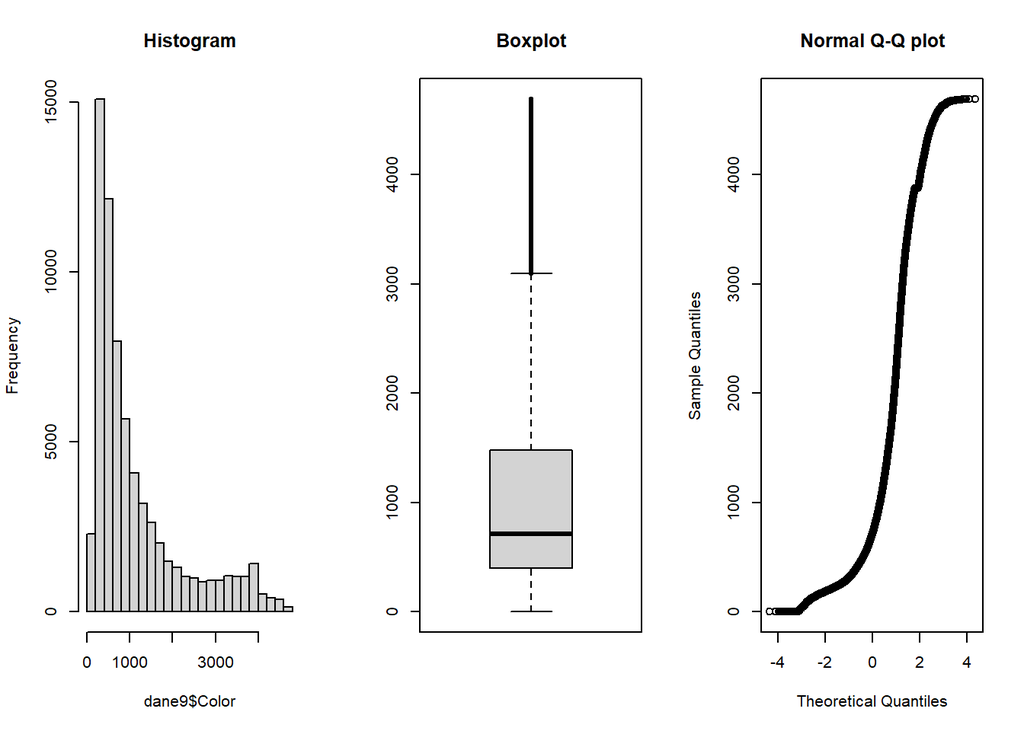

```r
par(mfrow = c(1, 3))
hist(dane9$Color, main = "Histogram")
boxplot(dane9$Color, main = "Boxplot")
qqnorm(dane9$Color, main = "Normal Q-Q plot")
```

**BoilSize** *Wykresy przed analizą wartości skrajnych*

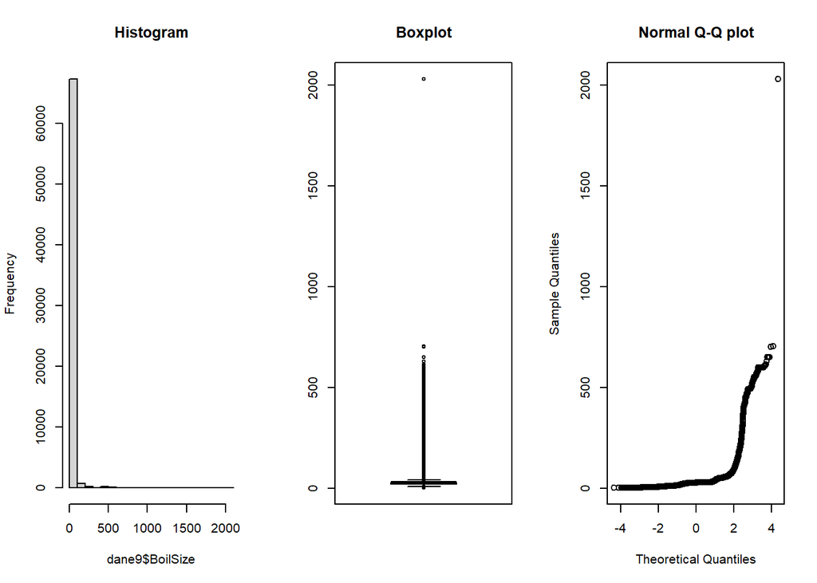

```r
par(mfrow = c(1, 3))
hist(dane9$BoilSize, main = "Histogram")
boxplot(dane9$BoilSize, main = "Boxplot")
qqnorm(dane9$BoilSize, main = "Normal Q-Q plot")
```

*Sprawdzenie czy zmienna ma rozkład normalny*

```r
ks.test(dane9$BoilSize, 'pnorm')
```

```
##
##  One-sample Kolmogorov-Smirnov test
##
## data:  dane9$BoilSize
## D = 0.99772, p-value < 2.2e-16
## alternative hypothesis: two-sided
```

**Wniosek: Zmienna nie ma rozkładu normalnego**

*Identyfikacja wartości skrajnych*

```r
#średnia i odchylenie standardowe
length(dane9$BeerID)
```

```
## [1] 68625
```

```r
mean = mean(dane9$BoilSize)
std = sd(dane9$BoilSize)

#wykorzystanie reguły 3 odchyleń
Tmin = mean-(3*std)
Tmax = mean+(3*std)

#znalezienie wartości skrajnych
head(dane9$BoilSize[which(dane9$BoilSize < Tmin | dane9$BoilSize > Tmax)],10)
```

```
##  [1] 179.81 490.00 181.70 210.00 177.91 189.27 210.00 484.53 435.32 405.00
```

```r
#usunięcie wartości skrajnych
dane9$id <- seq(1, length(dane9$StyleID))
ids <- dane9$id[which(dane9$BoilSize > Tmin & dane9$BoilSize < Tmax)]
dane10 <- subset(dane9[ids, ])
head(dane10,5)
```

```
##   BeerID StyleID Size.L.    OG    FG  ABV  IBU Color BoilSize BoilTime
## 1      1      45   21.77 1.004 1.004 5.48 1453   367    28.39       75
## 2      2      85   20.82 1.004 1.004 8.16 5749  1448    24.61       60
## 3      3       7   18.93 1.004 1.004 5.91 5610   782    22.71       60
## 4      4       7   22.71 1.004 1.004 5.80 5136   734    26.50       60
## 5      5      20   50.00 1.004 1.004 6.48 1472   341    60.00       90
##   BoilGravity Efficiency MashThickness BrewMethod PrimaryTemp id
## 1       1.004         70         2.127  All Grain          94  1
## 2       1.004         70         2.127  All Grain         121  2
## 3       1.005         70         2.127    extract         121  3
## 4       1.005         70         2.127  All Grain         121  4
## 5       1.004         72         2.127  All Grain         111  5
```

*Wykresy po analizie wartości skrajnych*

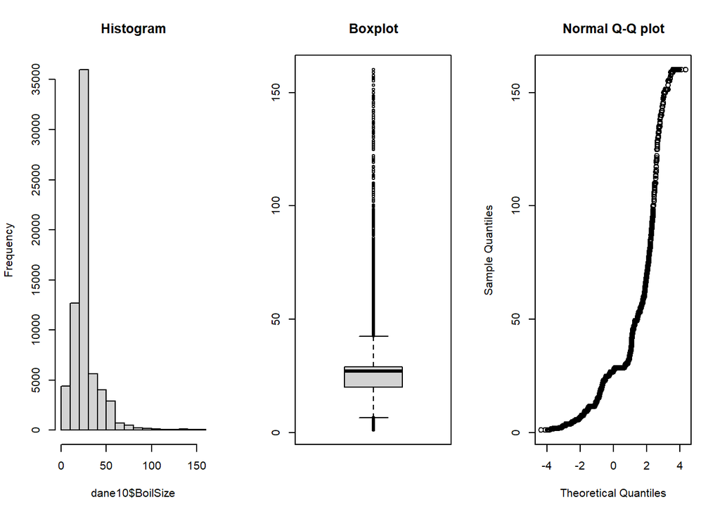

```r
par(mfrow = c(1, 3))
hist(dane10$BoilSize, main = "Histogram")
boxplot(dane10$BoilSize, main = "Boxplot")
qqnorm(dane10$BoilSize, main = "Normal Q-Q plot")
```

**BoilTime** *Wykresy przed analizą wartości skrajnych*

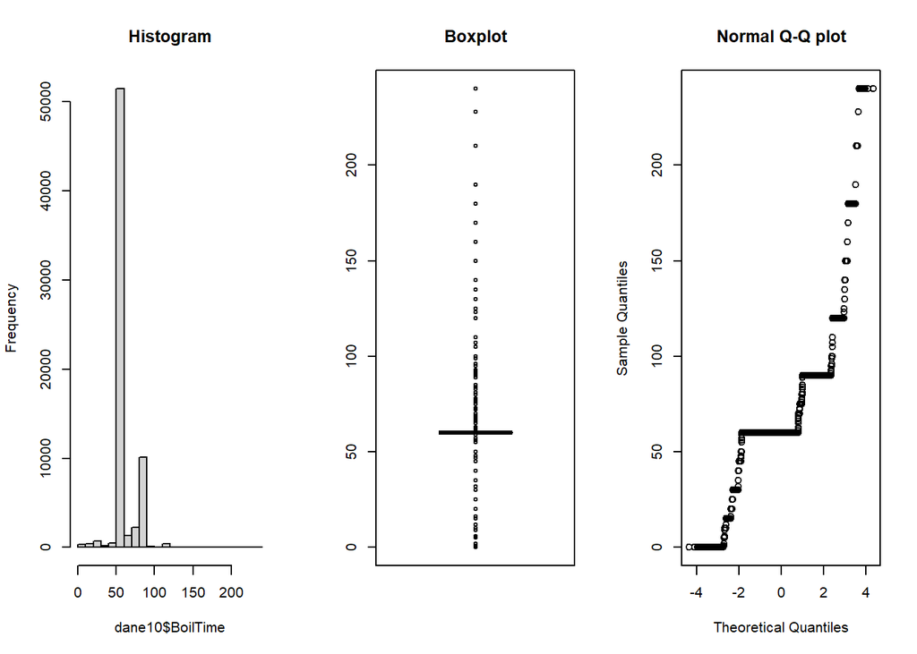

```r
par(mfrow = c(1, 3))
hist(dane10$BoilTime, main = "Histogram")
boxplot(dane10$BoilTime, main = "Boxplot")
qqnorm(dane10$BoilTime, main = "Normal Q-Q plot")
```

*Sprawdzenie czy zmienna ma rozkład normalny*

```r
ks.test(dane10$BoilTime, 'pnorm')
```

```
##
##  One-sample Kolmogorov-Smirnov test
##
## data:  dane10$BoilTime
## D = 0.99652, p-value < 2.2e-16
## alternative hypothesis: two-sided
```

**Wniosek: Zmienna nie ma rozkładu normalnego**

*Identyfikacja wartości skrajnych*

```r
#średnia i odchylenie standardowe
length(dane10$BeerID)
```

```
## [1] 67780
```

```r
mean = mean(dane10$BoilTime)
std = sd(dane10$BoilTime)

#wykorzystanie reguły 3 odchyleń
Tmin = mean-(3*std)
Tmax = mean+(3*std)

#znalezienie wartości skrajnych
head(dane10$BoilTime[which(dane10$BoilTime < Tmin | dane10$BoilTime > Tmax)],10)
```

```
##  [1]   0 120   0   0   1  20  15 170   0  15
```

```r
#usunięcie wartości skrajnych
dane10$id <- seq(1, length(dane10$StyleID))
ids <- dane10$id[which(dane10$BoilTime > Tmin & dane10$BoilTime < Tmax)]
dane11 <- subset(dane10[ids, ])
head(dane11,5)
```

```
##   BeerID StyleID Size.L.    OG    FG  ABV  IBU Color BoilSize BoilTime
## 1      1      45   21.77 1.004 1.004 5.48 1453   367    28.39       75
## 2      2      85   20.82 1.004 1.004 8.16 5749  1448    24.61       60
## 3      3       7   18.93 1.004 1.004 5.91 5610   782    22.71       60
## 4      4       7   22.71 1.004 1.004 5.80 5136   734    26.50       60
## 5      5      20   50.00 1.004 1.004 6.48 1472   341    60.00       90
##   BoilGravity Efficiency MashThickness BrewMethod PrimaryTemp id
## 1       1.004         70         2.127  All Grain          94  1
## 2       1.004         70         2.127  All Grain         121  2
## 3       1.005         70         2.127    extract         121  3
## 4       1.005         70         2.127  All Grain         121  4
## 5       1.004         72         2.127  All Grain         111  5
```

*Wykresy po analizie wartości skrajnych*

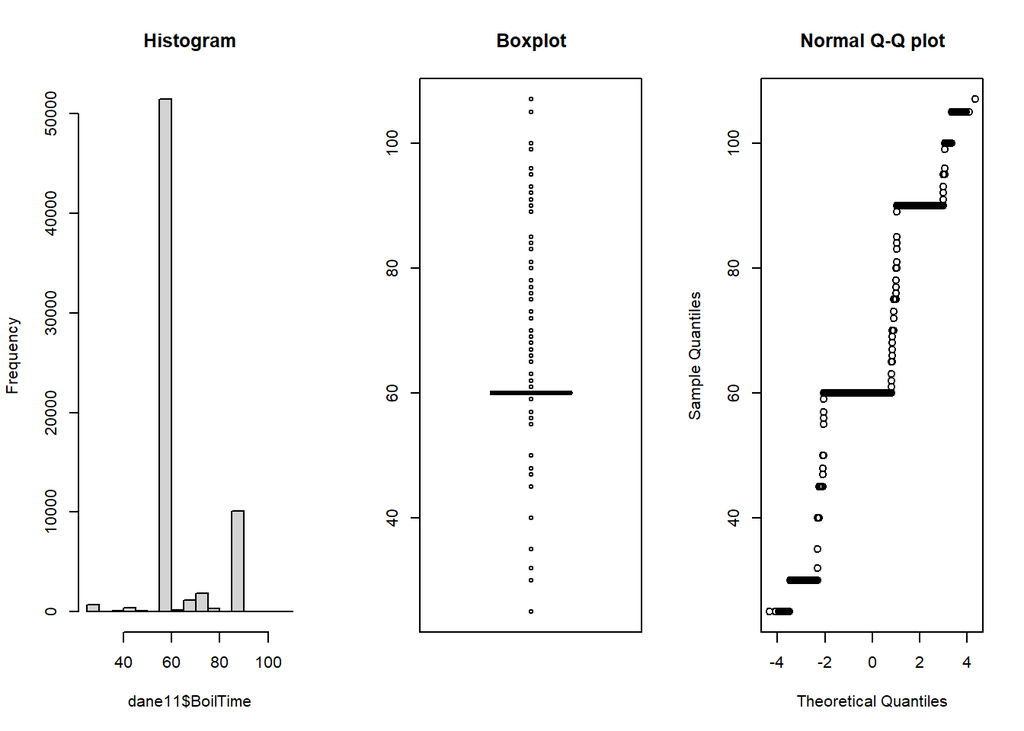

```r
par(mfrow = c(1, 3))
hist(dane11$BoilTime, main = "Histogram")
boxplot(dane11$BoilTime, main = "Boxplot")
qqnorm(dane11$BoilTime, main = "Normal Q-Q plot")
```

**BoilGravity** *Wykresy przed analizą wartości skrajnych*

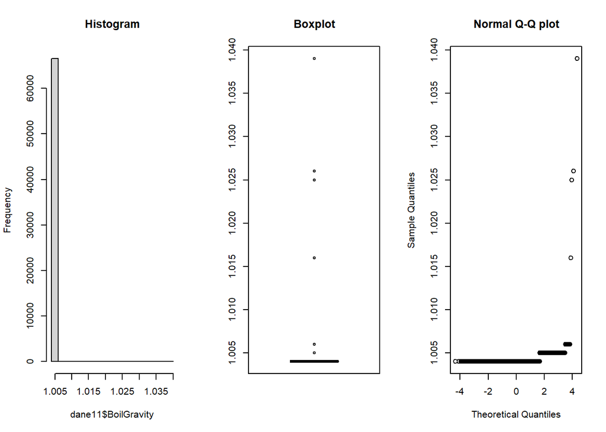

```r
par(mfrow = c(1, 3))
hist(dane11$BoilGravity, main = "Histogram")
boxplot(dane11$BoilGravity, main = "Boxplot")
qqnorm(dane11$BoilGravity, main = "Normal Q-Q plot")
```

*Sprawdzenie czy zmienna ma rozkład normalny*

```r
ks.test(dane11$BoilGravity, 'pnorm')
```

```
##
##  One-sample Kolmogorov-Smirnov test
##
## data:  dane11$BoilGravity
## D = 0.84231, p-value < 2.2e-16
## alternative hypothesis: two-sided
```

**Wniosek: Zmienna nie ma rozkładu normalnego**

*Identyfikacja wartości skrajnych*

```r
#średnia i odchylenie standardowe
length(dane11$BeerID)
```

```
## [1] 66525
```

```r
mean = mean(dane11$BoilGravity)
std = sd(dane11$BoilGravity)

#wykorzystanie reguły 3 odchyleń
Tmin = mean-(3*std)
Tmax = mean+(3*std)

#znalezienie wartości skrajnych
head(dane11$BoilGravity[which(dane11$BoilGravity < Tmin | dane11$BoilGravity > Tmax)],10)
```

```
##  [1] 1.005 1.005 1.005 1.005 1.005 1.005 1.005 1.005 1.005 1.005
```

```r
#usunięcie wartości skrajnych
dane11$id <- seq(1, length(dane11$StyleID))
ids <- dane11$id[which(dane11$BoilGravity > Tmin & dane11$BoilGravity < Tmax)]
dane12 <- dane11
head(dane12,5)
```

```
##   BeerID StyleID Size.L.    OG    FG  ABV  IBU Color BoilSize BoilTime
## 1      1      45   21.77 1.004 1.004 5.48 1453   367    28.39       75
## 2      2      85   20.82 1.004 1.004 8.16 5749  1448    24.61       60
## 3      3       7   18.93 1.004 1.004 5.91 5610   782    22.71       60
## 4      4       7   22.71 1.004 1.004 5.80 5136   734    26.50       60
## 5      5      20   50.00 1.004 1.004 6.48 1472   341    60.00       90
##   BoilGravity Efficiency MashThickness BrewMethod PrimaryTemp id
## 1       1.004         70         2.127  All Grain          94  1
## 2       1.004         70         2.127  All Grain         121  2
## 3       1.005         70         2.127    extract         121  3
## 4       1.005         70         2.127  All Grain         121  4
## 5       1.004         72         2.127  All Grain         111  5
```

**Ze zmiennej `BoilGravity` wartości skrajne nie będą usuwane.**

**Efficiency - zmienna będzie podlegać analizie wartości skrajnych, ponieważ efektywność wyrażana jest w postaci liczbowej** *Wykresy przed analizą wartości skrajnych*

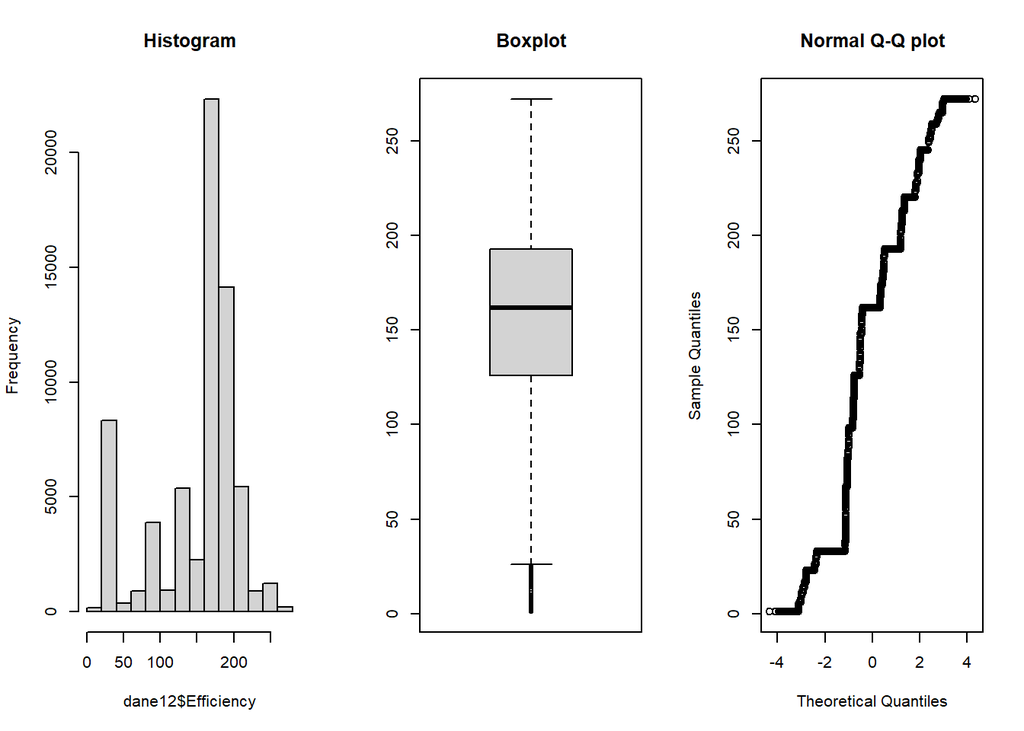

```r
dane12$Efficiency<-as.numeric(dane12$Efficiency)
par(mfrow = c(1, 3))
hist(dane12$Efficiency, main = "Histogram")
boxplot(dane12$Efficiency, main = "Boxplot")
qqnorm(dane12$Efficiency, main = "Normal Q-Q plot")
```

*Sprawdzenie czy zmienna ma rozkład normalny*

```r
ks.test(dane12$Efficiency, 'pnorm')
```

```
##
##  One-sample Kolmogorov-Smirnov test
##
## data:  dane12$Efficiency
## D = 0.99904, p-value < 2.2e-16
## alternative hypothesis: two-sided
```

**Wniosek: Zmienna nie ma rozkładu normalnego**

*Identyfikacja wartości skrajnych*

```r
#średnia i odchylenie standardowe
length(dane12$BeerID)
```

```
## [1] 66525
```

```r
mean = mean(dane12$Efficiency)
std = sd(dane12$Efficiency)

#wykorzystanie reguły 3 odchyleń
Tmin = mean-(3*std)
Tmax = mean+(3*std)

#znalezienie wartości skrajnych
head(dane12$Efficiency[which(dane12$Efficiency < Tmin | dane12$Efficiency > Tmax)],10)
```

```
## numeric(0)
```

```r
#usunięcie wartości skrajnych
dane12$id <- seq(1, length(dane12$StyleID))
ids <- dane12$id[which(dane12$Efficiency > Tmin & dane12$Efficiency < Tmax)]
dane13 <- subset(dane12[ids, ])
head(dane13,5)
```

```
##   BeerID StyleID Size.L.    OG    FG  ABV  IBU Color BoilSize BoilTime
## 1      1      45   21.77 1.004 1.004 5.48 1453   367    28.39       75
## 2      2      85   20.82 1.004 1.004 8.16 5749  1448    24.61       60
## 3      3       7   18.93 1.004 1.004 5.91 5610   782    22.71       60
## 4      4       7   22.71 1.004 1.004 5.80 5136   734    26.50       60
## 5      5      20   50.00 1.004 1.004 6.48 1472   341    60.00       90
##   BoilGravity Efficiency MashThickness BrewMethod PrimaryTemp id
## 1       1.004        162         2.127  All Grain          94  1
## 2       1.004        162         2.127  All Grain         121  2
## 3       1.005        162         2.127    extract         121  3
## 4       1.005        162         2.127  All Grain         121  4
## 5       1.004        174         2.127  All Grain         111  5
```

**Zmienna `Efficiency` nie posiada wartości skrajnych.**

**MashThickness** *Wykresy przed analizą wartości skrajnych*

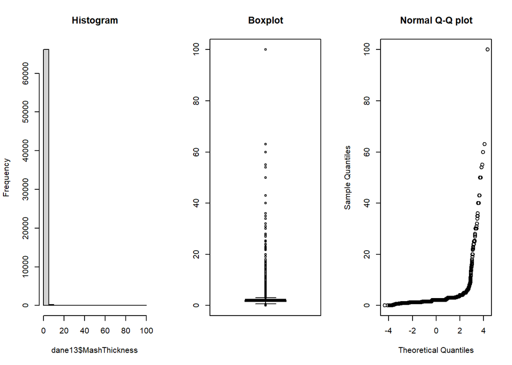

```r
par(mfrow = c(1, 3))
hist(dane13$MashThickness, main = "Histogram")
boxplot(dane13$MashThickness, main = "Boxplot")
qqnorm(dane13$MashThickness, main = "Normal Q-Q plot")
```

*Sprawdzenie czy zmienna ma rozkład normalny*

```r
ks.test(dane13$MashThickness, 'pnorm')
```

```
##
##  One-sample Kolmogorov-Smirnov test
##
## data:  dane13$MashThickness
## D = 0.87267, p-value < 2.2e-16
## alternative hypothesis: two-sided
```

**Wniosek: Zmienna nie ma rozkładu normalnego**

*Identyfikacja wartości skrajnych*

```r
#średnia i odchylenie standardowe
length(dane13$BeerID)
```

```
## [1] 66525
```

```r
mean = mean(dane13$MashThickness)
std = sd(dane13$MashThickness)

#wykorzystanie reguły 3 odchyleń
Tmin = mean-(3*std)
Tmax = mean+(3*std)

#znalezienie wartości skrajnych
head(dane13$MashThickness[which(dane13$MashThickness < Tmin | dane13$MashThickness > Tmax)],10)
```

```
##  [1]  6.097  6.700  6.250  6.127  6.142 36.000 14.000  6.300 24.000 15.000
```

```r
#usunięcie wartości skrajnych
dane13$id <- seq(1, length(dane13$StyleID))
ids <- dane13$id[which(dane13$MashThickness > Tmin & dane13$MashThickness < Tmax)]
dane14 <- subset(dane13[ids, ])
head(dane14,5)
```

```
##   BeerID StyleID Size.L.    OG    FG  ABV  IBU Color BoilSize BoilTime
## 1      1      45   21.77 1.004 1.004 5.48 1453   367    28.39       75
## 2      2      85   20.82 1.004 1.004 8.16 5749  1448    24.61       60
## 3      3       7   18.93 1.004 1.004 5.91 5610   782    22.71       60
## 4      4       7   22.71 1.004 1.004 5.80 5136   734    26.50       60
## 5      5      20   50.00 1.004 1.004 6.48 1472   341    60.00       90
##   BoilGravity Efficiency MashThickness BrewMethod PrimaryTemp id
## 1       1.004        162         2.127  All Grain          94  1
## 2       1.004        162         2.127  All Grain         121  2
## 3       1.005        162         2.127    extract         121  3
## 4       1.005        162         2.127  All Grain         121  4
## 5       1.004        174         2.127  All Grain         111  5
```

*Wykresy po analizie wartości skrajnych*

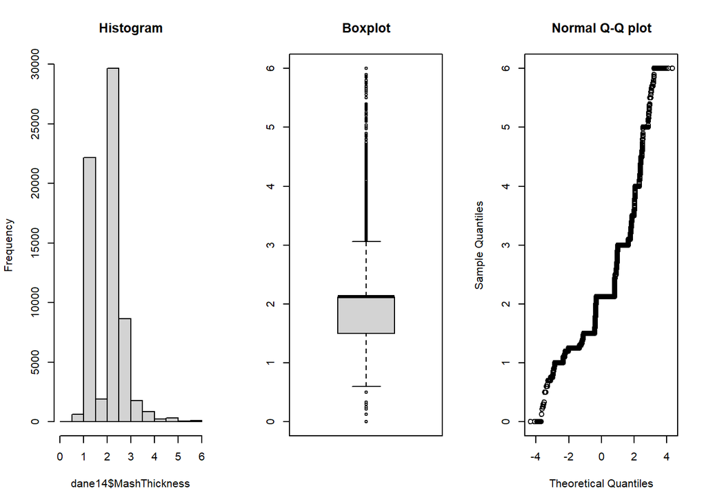

```r
par(mfrow = c(1, 3))
hist(dane14$MashThickness, main = "Histogram")
boxplot(dane14$MashThickness, main = "Boxplot")
qqnorm(dane14$MashThickness, main = "Normal Q-Q plot")
```

**BrewMethod - zmienna nie będzie podlegać analizie wartości skrajnych, ponieważ są to tylko 4 rodzaje metod i nie ma tu jednostek skrajnych lub nieskrajnych**

**PrimaryTemp** *Wykresy przed analizą wartości skrajnych*

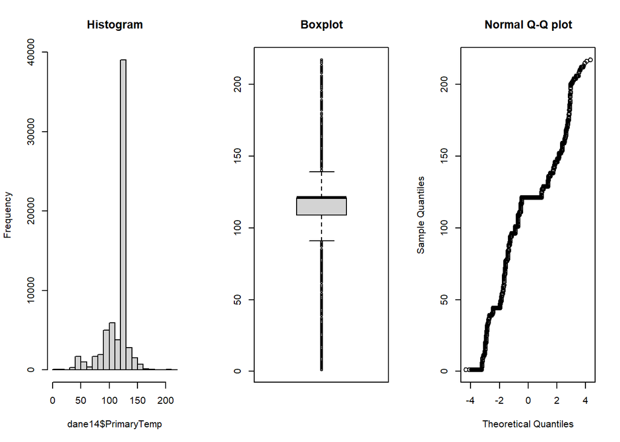

```r
dane14$PrimaryTemp<-as.numeric(dane14$PrimaryTemp)
par(mfrow = c(1, 3))
hist(dane14$PrimaryTemp, main = "Histogram")
boxplot(dane14$PrimaryTemp, main = "Boxplot")
qqnorm(dane14$PrimaryTemp, main = "Normal Q-Q plot")
```

*Sprawdzenie czy zmienna ma rozkład normalny*

```r
ks.test(dane14$PrimaryTemp, 'pnorm')
```

```
##
##  One-sample Kolmogorov-Smirnov test
##
## data:  dane14$PrimaryTemp
## D = 0.99932, p-value < 2.2e-16
## alternative hypothesis: two-sided
```

**Wniosek: Zmienna nie ma rozkładu normalnego**

*Identyfikacja wartości skrajnych*

```r
#średnia i odchylenie standardowe
length(dane14$BeerID)
```

```
## [1] 66273
```

```r
mean = mean(dane14$PrimaryTemp)
std = sd(dane14$PrimaryTemp)

#wykorzystanie reguły 3 odchyleń
Tmin = mean-(3*std)
Tmax = mean+(3*std)

#znalezienie wartości skrajnych
head(dane14$PrimaryTemp[which(dane14$PrimaryTemp < Tmin | dane14$PrimaryTemp > Tmax)],10)
```

```
##  [1] 44 47 44 44 44 44 49 44 44 44
```

```r
#usunięcie wartości skrajnych
dane14$id <- seq(1, length(dane14$StyleID))
ids <- dane14$id[which(dane14$PrimaryTemp > Tmin & dane14$PrimaryTemp < Tmax)]
dane15 <- subset(dane14[ids, ])
head(dane15,5)
```

```
##   BeerID StyleID Size.L.    OG    FG  ABV  IBU Color BoilSize BoilTime
## 1      1      45   21.77 1.004 1.004 5.48 1453   367    28.39       75
## 2      2      85   20.82 1.004 1.004 8.16 5749  1448    24.61       60
## 3      3       7   18.93 1.004 1.004 5.91 5610   782    22.71       60
## 4      4       7   22.71 1.004 1.004 5.80 5136   734    26.50       60
## 5      5      20   50.00 1.004 1.004 6.48 1472   341    60.00       90
##   BoilGravity Efficiency MashThickness BrewMethod PrimaryTemp id
## 1       1.004        162         2.127  All Grain          94  1
## 2       1.004        162         2.127  All Grain         121  2
## 3       1.005        162         2.127    extract         121  3
## 4       1.005        162         2.127  All Grain         121  4
## 5       1.004        174         2.127  All Grain         111  5
```

*Wykresy po analizie wartości skrajnych*

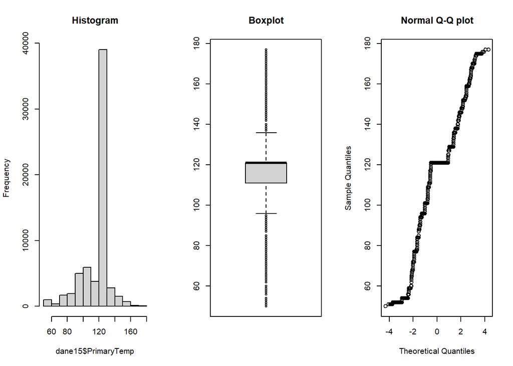

```r
par(mfrow = c(1, 3))
hist(dane15$PrimaryTemp, main = "Histogram")
boxplot(dane15$PrimaryTemp, main = "Boxplot")
qqnorm(dane15$PrimaryTemp, main = "Normal Q-Q plot")
```

**b. Podjęcie decyzji: usunięcie czy pozostawienie wartości skrajnych w zbiorze** Wszystkie wartości skrajne w zbiorze stanowią 17% wszystkich rekordów. Wartości skrajne dla zmiennych FG oraz BoilGravity nie zostały usunięte, ponieważ spowodowałoby to, że obie zmienne przyjęłyby niemalże jedną watrość dla wszystkich rekordów, zatem stałyby się bezużyteczne. Dla zmiennej Efficiency nie odnotowano jednostek skrajnych. Pozostałe rekordy będące wartościami skrajnymi stanowią 13,35% zbioru wszystkich jednostek. Pomimo, że jest to duża wartość, w celu osiągnięcia lepszych wyników w analizie do, której dane są przygotowywane, postanowiono usunąć wspomniane 13,35% jednostek ze zbioru.

**Nadpisanie zmiennych do dalszej części bez identyfikatora grupy i zmiennej BeerID**

```r
dane16<-dane15[,-c(1,16)]
head(dane16,10)
```

```
##    StyleID Size.L.    OG    FG  ABV  IBU Color BoilSize BoilTime BoilGravity
## 1       45   21.77 1.004 1.004 5.48 1453   367    28.39       75       1.004
## 2       85   20.82 1.004 1.004 8.16 5749  1448    24.61       60       1.004
## 3        7   18.93 1.004 1.004 5.91 5610   782    22.71       60       1.005
## 4        7   22.71 1.004 1.004 5.80 5136   734    26.50       60       1.005
## 5       20   50.00 1.004 1.004 6.48 1472   341    60.00       90       1.004
## 6       10   24.61 1.004 1.004 5.58 3700   684    29.34       70       1.004
## 8       45   20.82 1.004 1.004 5.36 1685   478    28.39       75       1.004
## 9      129   22.71 1.004 1.004 5.77 2851  3351    30.28       75       1.004
## 10      86   20.82 1.004 1.004 8.22 8776   713    28.39       60       1.004
## 11       7   25.00 1.004 1.004 6.63 6109   662    29.00       90       1.004
##    Efficiency MashThickness BrewMethod PrimaryTemp
## 1         162         2.127  All Grain          94
## 2         162         2.127  All Grain         121
## 3         162         2.127    extract         121
## 4         162         2.127  All Grain         121
## 5         174         2.127  All Grain         111
## 6         217         2.127  All Grain         121
## 8         162         1.400  All Grain         121
## 9         181         2.127  All Grain         121
## 10        162         2.127  All Grain         129
## 11        189         2.127  All Grain          96
```

*5. Wybór zmiennych do badania*

**a. Wybranie metody doboru zmiennych z uzasadnieniem wyboru.**

*Aby sprawdzić, które zmienne należy wybrać do estymacji modelu liniowego zastosowano analizę korelacji zmiennych. Pozwala ona na sprawdzenie siły związku liniowego pomiędzy dwoma zmiennymi.*

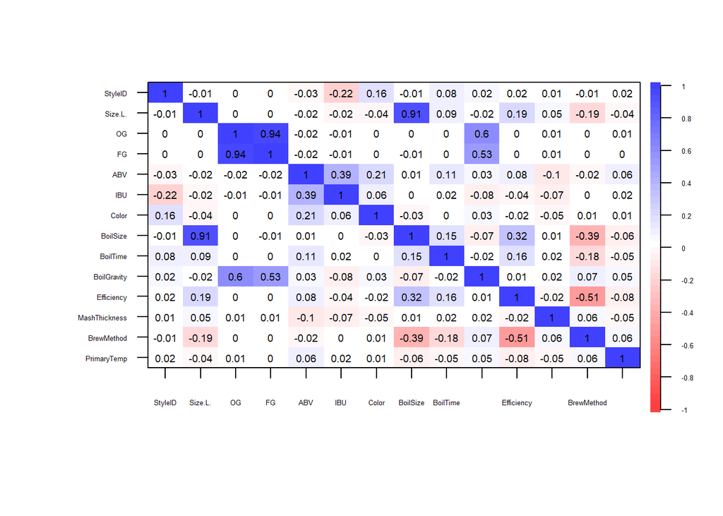

```r
dane16$StyleID<-as.numeric(dane16$StyleID)
dane16$BrewMethod<-as.numeric(dane16$BrewMethod)
k=cor(dane16)
corPlot(k, cex = 0.6, cex.axis=0.4,cex.lab=2)
```

*Również w celu sprawdzenia zależności pomiędzy zmiennymi zastosowano analizę wariancji. ANOVA jest testem statystycznym służącym do szacowania zmian ilościowej zmiennej zależnej w zależności od poziomu jednej lub większej liczby niezależnych zmiennych jakościowych. ANOVA sprawdza, czy istnieje różnica w średnich grup na każdym poziomie zmiennej niezależnej.*

```r
aov1 <- aov(ABV ~ StyleID+Size.L.+IBU+Color+BoilSize+BoilTime+BoilGravity+Efficiency+MashThickness++BrewMethod+PrimaryTemp,data = dane16)
summary(aov1)
```

```
##                  Df Sum Sq Mean Sq  F value   Pr(>F)
## StyleID           1    102     102    62.73 2.41e-15 ***
## Size.L.           1     47      47    29.31 6.18e-08 ***
## IBU               1  20752   20752 12821.09  < 2e-16 ***
## Color             1   4456    4456  2753.10  < 2e-16 ***
## BoilSize          1    241     241   148.84  < 2e-16 ***
## BoilTime          1   1214    1214   749.91  < 2e-16 ***
## BoilGravity       1    456     456   281.45  < 2e-16 ***
## Efficiency        1    887     887   548.31  < 2e-16 ***
## MashThickness     1    530     530   327.36  < 2e-16 ***
## BrewMethod        1    224     224   138.60  < 2e-16 ***
## PrimaryTemp       1    488     488   301.33  < 2e-16 ***
## Residuals     63990 103574       2
## ---
## Signif. codes:  0 '***' 0.001 '**' 0.01 '*' 0.05 '.' 0.1 ' ' 1
```

```r
cat("\n")
```

```r
aov2 <- aov(ABV ~ StyleID+IBU+Color+BoilSize+BoilTime+BoilGravity+Efficiency+MashThickness+BrewMethod+PrimaryTemp,data = dane16)
summary(aov2)
```

```
##                  Df Sum Sq Mean Sq  F value   Pr(>F)
## StyleID           1    102     102    62.69 2.45e-15 ***
## IBU               1  20790   20790 12837.57  < 2e-16 ***
## Color             1   4465    4465  2757.06  < 2e-16 ***
## BoilSize          1     35      35    21.69 3.21e-06 ***
## BoilTime          1   1312    1312   810.14  < 2e-16 ***
## BoilGravity       1    405     405   250.09  < 2e-16 ***
## Efficiency        1   1026    1026   633.83  < 2e-16 ***
## MashThickness     1    543     543   335.15  < 2e-16 ***
## BrewMethod        1    175     175   108.28  < 2e-16 ***
## PrimaryTemp       1    485     485   299.51  < 2e-16 ***
## Residuals     63991 103633       2
## ---
## Signif. codes:  0 '***' 0.001 '**' 0.01 '*' 0.05 '.' 0.1 ' ' 1
```

```r
cat("\n")
```

```r
aov3 <- aov(ABV ~ StyleID+Size.L.+IBU+Color+BoilTime+BoilGravity+Efficiency+MashThickness+BrewMethod+PrimaryTemp,data = dane16)
summary(aov3)
```

```
##                  Df Sum Sq Mean Sq  F value   Pr(>F)
## StyleID           1    102     102    62.71 2.44e-15 ***
## Size.L.           1     47      47    29.30 6.21e-08 ***
## IBU               1  20752   20752 12817.20  < 2e-16 ***
## Color             1   4456    4456  2752.27  < 2e-16 ***
## BoilTime          1   1362    1362   841.18  < 2e-16 ***
## BoilGravity       1    399     399   246.55  < 2e-16 ***
## Efficiency        1   1036    1036   639.95  < 2e-16 ***
## MashThickness     1    530     530   327.21  < 2e-16 ***
## BrewMethod        1    196     196   121.15  < 2e-16 ***
## PrimaryTemp       1    483     483   298.55  < 2e-16 ***
## Residuals     63991 103607       2
## ---
## Signif. codes:  0 '***' 0.001 '**' 0.01 '*' 0.05 '.' 0.1 ' ' 1
```

**Wniosek:** Ponieważ różnice są bardzo małe zadecydowano o usunięciu zmiennej Size.L., ponieważ zmienna BoilSize tworzy wyższe wartości korelacji z innymi zmiennymi, a w przypadku analizy wariancji obie zmienne są istotne na tym samym poziomie istotności.

*6. Wybór jednostek do badania.*

**Nadpisanie zmiennych w celu wyboru jednostek do badania**

```r
dane17<-dane16[,-c(2,3,4)]
head(dane17,10)
```

```
##    StyleID  ABV  IBU Color BoilSize BoilTime BoilGravity Efficiency
## 1       45 5.48 1453   367    28.39       75       1.004        162
## 2       85 8.16 5749  1448    24.61       60       1.004        162
## 3        7 5.91 5610   782    22.71       60       1.005        162
## 4        7 5.80 5136   734    26.50       60       1.005        162
## 5       20 6.48 1472   341    60.00       90       1.004        174
## 6       10 5.58 3700   684    29.34       70       1.004        217
## 8       45 5.36 1685   478    28.39       75       1.004        162
## 9      129 5.77 2851  3351    30.28       75       1.004        181
## 10      86 8.22 8776   713    28.39       60       1.004        162
## 11       7 6.63 6109   662    29.00       90       1.004        189
##    MashThickness BrewMethod PrimaryTemp
## 1          2.127          1          94
## 2          2.127          1         121
## 3          2.127          3         121
## 4          2.127          1         121
## 5          2.127          1         111
## 6          2.127          1         121
## 8          1.400          1         121
## 9          2.127          1         121
## 10         2.127          1         129
## 11         2.127          1          96
```

**a. Wybranie schematu losowania z uzasadnieniem wyboru.**

*Jako kategorię, z której zostaną wylosowane jednostki wybrano BrewMethod - technikę ważenia piwa, która zdecydowanie ma duży wpływ na zawartość procentową alkoholu w piwie*

```r
los_jed = strata(dane17, c("BrewMethod"),size = c(3000,3000,3000,3000), method = "srswor")
head(los_jed,10)
```

```
##     BrewMethod ID_unit       Prob Stratum
## 25           1      25 0.07127753       1
## 89           1      89 0.07127753       1
## 98           1      98 0.07127753       1
## 106          1     106 0.07127753       1
## 107          1     107 0.07127753       1
## 134          1     134 0.07127753       1
## 136          1     136 0.07127753       1
## 161          1     161 0.07127753       1
## 179          1     179 0.07127753       1
## 219          1     219 0.07127753       1
```

```r
dane_finalne=dane17[los_jed$ID_unit,]
head(dane_finalne,10)
```

```
##     StyleID   ABV  IBU Color BoilSize BoilTime BoilGravity Efficiency
## 26       10  6.60    1  1053    18.93       60       1.005        193
## 97        7  5.73 3940   444    28.39       60       1.004        126
## 106     114  6.39 3181  3872    28.39       60       1.004        162
## 115      23  8.59 6845   562    53.00       90       1.004        206
## 116       7  6.88 6186   559    50.00       60       1.004        162
## 143      21 10.72 4369  3872    27.44       90       1.005        193
## 145     156  4.23  787   205    49.21       90       1.005        174
## 173      27  3.87  364   173    53.00       45       1.005        174
## 194     144  4.25 3186  1217    26.50       60       1.004        220
## 237      10  5.57 6627   423    60.57       90       1.005        162
##     MashThickness BrewMethod PrimaryTemp
## 26          2.127          1         121
## 97          1.500          1         121
## 106         1.250          1         121
## 115         2.127          1         159
## 116         2.127          1          96
## 143         2.127          1         121
## 145         2.127          1         121
## 173         2.127          1         121
## 194         2.127          1          96
## 237         2.127          1         121
```